# Классификация заемщиков кредита с помощью логистической регрессии

## Московский физико-технический институт

### Соколов Игорь Александрович

## Постановка задачи

#### Задача

Классифицировать заемщиков кредита с помощью логистической регрессии.

- Рассмотреть регуляризаторы L1, L2, подобрать наилучшие параметры по метрике roc_auc

Пусть объекты описываются $n$ числовыми признаками:

$X \subseteq \mathbb{R}^n$ - пространство признаковых описаний объектов.

Y = {+1, -1} - множество меток классов.

Задана обучающая выборка: $\{(x_i, y_i)\}_1^l$

Наша задачи найти линейный алгоритм классификации:

$$a(x, w) = sign\langle w, x\rangle$$

Параметры $w$ и находятся, как решения следующей задачи оптимизации:

L2-regularization:

$$ Q(X, y) = \frac{1}{2} w^T w + C \sum_{i=1}^l \log ( 1 + \exp(-y_i (w^T x_i) ) ) \longrightarrow \min\limits_{w,b} $$

L1-regularization:

$$ Q(X, y) = \sum_{d=1}^D |w_d| + C \sum_{i=1}^l \log ( 1 + \exp(-y_i (w^T x_i ) ) ) \longrightarrow \min\limits_{w,b} $$

$C$ - это стандартный гиперпараметр модели, который регулирует то, насколько сильно мы позволяем модели подстраиваться под данные.

## Обзор данных

```python
df = pd.read_csv('data.csv')
df.head(5)
```

|  | A1 | A2 | A3 | A4 | A5 | A6 | A7 | A8 | A9 | A10 | A11 | A12 | A13 | A14 | A15 | A16 |
| --- | --- | --- | --- | --- | --- | --- | --- | --- | --- | --- | --- | --- | --- | --- | --- | --- |
| 0 | b | 30.83 | 0.000 | u | g | w | v | 1.25 | t | t | 1 | f | g | 00202 | 0 | + |
| 1 | a | 58.67 | 4.460 | u | g | q | h | 3.04 | t | t | 6 | f | g | 00043 | 560 | + |
| 2 | a | 24.50 | 0.500 | u | g | q | h | 1.50 | t | f | 0 | f | g | 00280 | 824 | + |
| 3 | b | 27.83 | 1.540 | u | g | w | v | 3.75 | t | t | 5 | t | g | 00100 | 3 | + |
| 4 | b | 20.17 | 5.625 | u | g | w | v | 1.71 | t | f | 0 | f | s | 00120 | 0 | + |

- **A2, A3, A8, A11, A14, A15**: вещественные.
- **A1**: b, a.
- **A4**: u, y, l, t.
- **A5**: g, p, gg.
- **A6**: c, d, cc, i, j, k, m, r, q, w, x, e, aa, ff.
- **A7**: v, h, bb, j, n, z, dd, ff, o.
- **A9, A10, A12**: t, f.
- **A13**: g, p, s.
- **A16**: +,- атрибут класса

Так как некоторые и признаков категориальные, то для для построения линейной модели необходима предобработка.

## Измерение качества

[figure not shown]

**Мера качества** auc-roc

## Предобработка данных

### Обработка пропущенных значений и преобразование вещественных признаков

На место пропуска можно вставить либо среднее по столбцу либо 0.

Далее рассмотрим два варианта.

```python
X['A2'] = X['A2'].apply(lambda x: np.NaN if x =='?' else x)
X['A14'] = X['A14'].apply(lambda x: np.NaN if x =='?' else x)

X_num_float = X[numeric_cols].astype(float)
nan_id = np.argwhere(np.isnan(X_num_float['A14'].values))

X_real_zeros = X_num_float.fillna(0.0)
X_real_mean = X_num_float.fillna(calculate_means(X_num_float))

X_cat = X[categorical_cols].astype(str)

#Преобразование ответов
y_num = y.apply(lambda x: 1 if x=='+' else -1)
```

### Преобразование категориальных признаков

```python
set(X_cat['A5'].values)
```

```
{'?', 'g', 'gg', 'p'}
```

$? \rightarrow (1, 0, 0, 0)$

$g \rightarrow (0, 1, 0, 0)$

$gg \rightarrow (0, 0, 1, 0)$

$p \rightarrow (0, 0, 0, 1)$

```python
encoder = DV(sparse = False)
X_cat_oh = encoder.fit_transform(X_cat.T.to_dict().values())
```

### Стандартизация

Построим гистограммы для вещественных признаков.

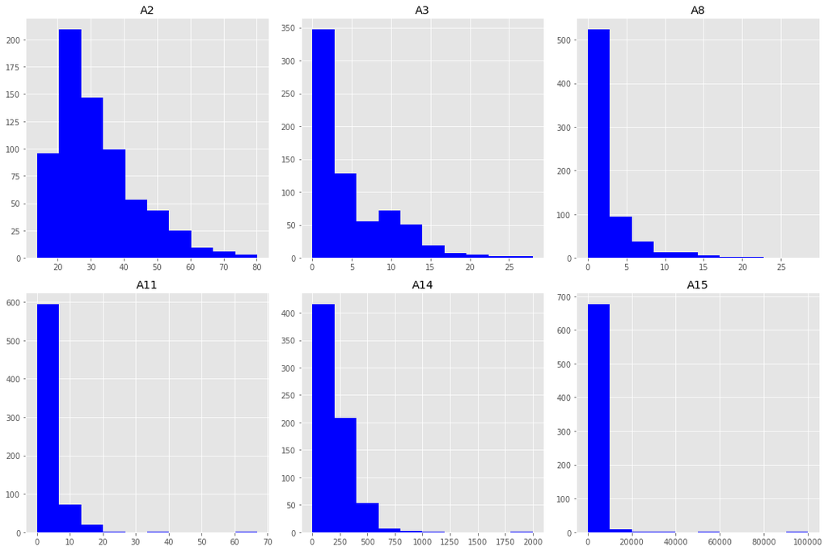

```python
plot_hists()
```

Как видно из графиков, разные признаки очень сильно отличаются друг от друга по модулю значений.

При использовании регуляризации, которая штрафует модель за большие веса, это разброс начинает сказываться и регрессия, как правило, начинает работать хуже.

Стандартизация осуществляется посредством вычета из каждого признака среднего значения и нормировки на выборочное стандартное отклонение:

$$ x^{scaled}_{i} = \dfrac{x_{i} - \mu}{\sigma}, \quad \mu = \frac{1}{N} \sum_{i=1}^l x_{i}, \quad \sigma = \sqrt{\frac{1}{N-1} \sum_{i=1}^l (x_{i} - \mu)^2} $$

$\mu$ и $\sigma$ вычисляется именно по тренировочным данным.

Мы считаем, что и тренировочные и тестовые данные находится в одном распределении, поэтому делаем преобразование над тестовой выборкой с такими же $\mu$ и $\sigma$

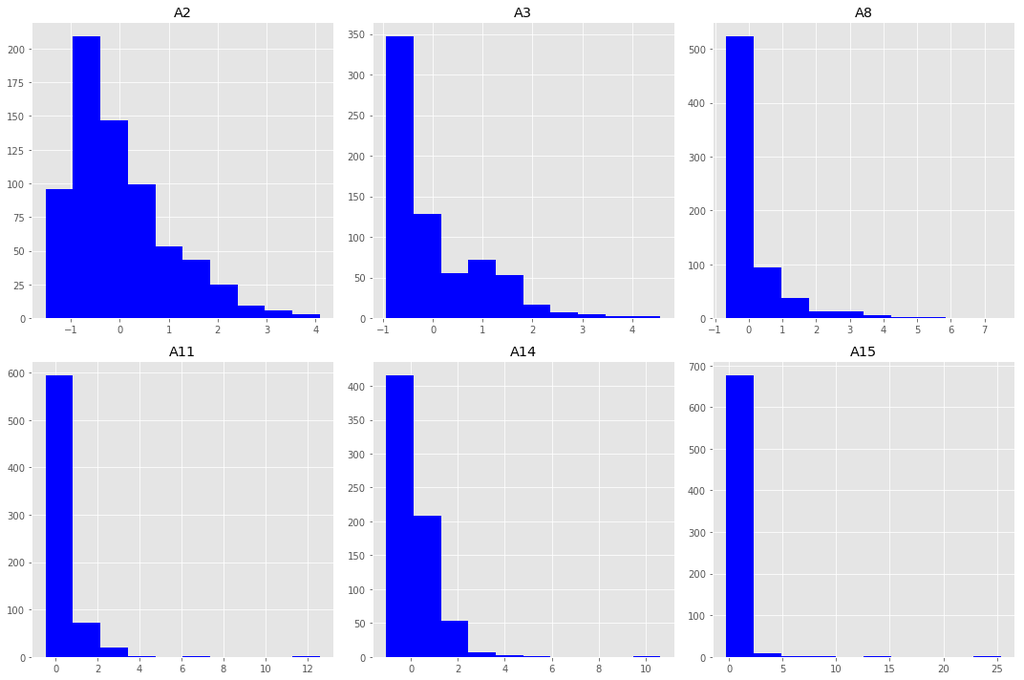

```python
plot_hists_scaled()
```

## Обучение

Используем L2-регулярирзацию

```python
C = np.arange(0.01, 50.0, 0.5)
param_grid = {'C': C, 'solver':['liblinear']}
cv = StratifiedKFold(y_train, n_folds=5, shuffle=True, random_state=0)

est2_m = LR('l2')
est2_z = LR('l2')
est2_ms = LR('l2')
est2_zs = LR('l2')


opt2_m = GridSearchCV(est2_m,param_grid,scoring = 'roc_auc',cv=cv)
opt2_z = GridSearchCV(est2_z,param_grid,scoring = 'roc_auc',cv=cv)

opt2_ms = GridSearchCV(est2_ms,param_grid,scoring = 'roc_auc',cv=cv)
opt2_zs = GridSearchCV(est2_zs,param_grid,scoring = 'roc_auc',cv=cv)
```

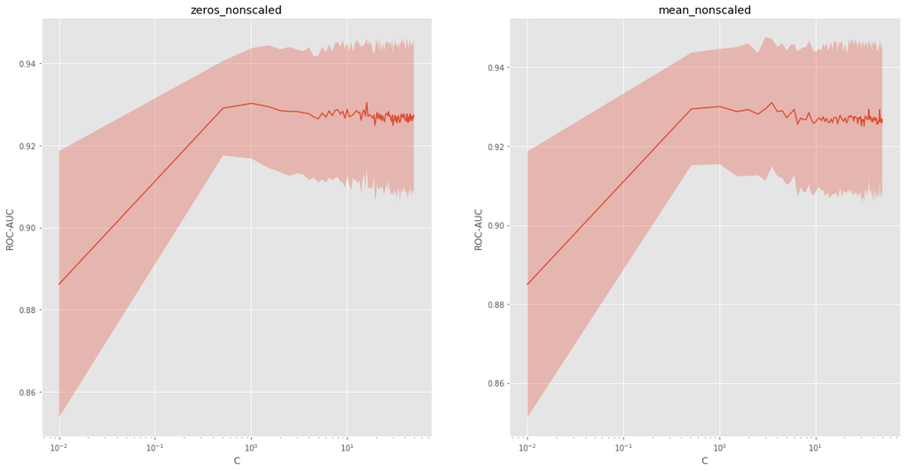

```python
plot_scores(opt2_z, opt2_m,["zeros_nonscaled","mean_nonscaled"])
```

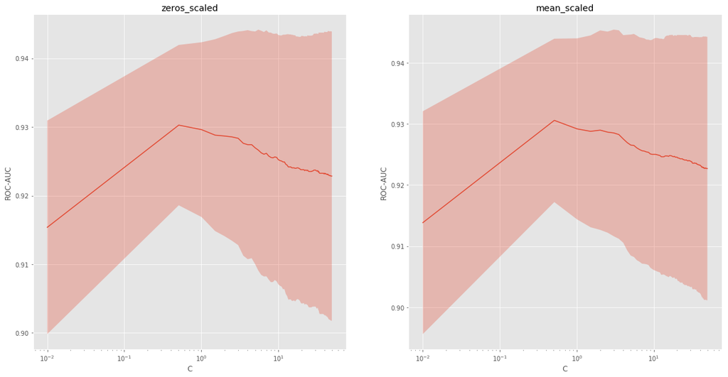

```python
plot_scores(opt2_zs, opt2_ms,["zeros_scaled","mean_scaled"])
```

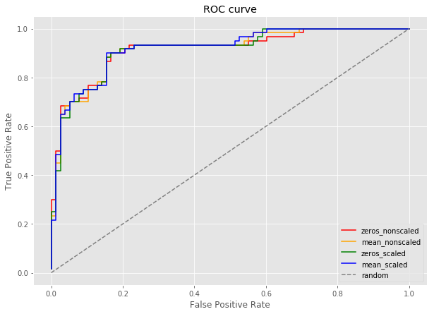

```python
fpr1, tpr1, _ = roc_curve(y_test, opt2_z.predict_proba(X_test_zeros)[:,1])
fpr2, tpr2, _ = roc_curve(y_test, opt2_m.predict_proba(X_test_mean)[:,1])
fpr3, tpr3, _ = roc_curve(y_test, opt2_zs.predict_proba(X_test_zeros_scaled)[:,1])
fpr4, tpr4, _ = roc_curve(y_test, opt2_ms.predict_proba(X_test_mean_scaled)[:,1])
plot_roc((fpr1,fpr2, fpr3,fpr4), (tpr1, tpr2,tpr3, tpr4),
("zeros_nonscaled","mean_nonscaled", "zeros_scaled","mean_scaled"), ("red","orange","green","blue"))
```

```python
print_results2()
```

[output not shown]

Возрос auc_roc на на той выборке, где пропуски заменены нулями.

### Попробуем L1-регуляризацию

```python
C = np.arange(0.01, 50.0, 0.5)
param_grid = {'C': C, 'solver':['liblinear']}
cv = StratifiedKFold(y_train, n_folds=5, shuffle=True, random_state=0)

est1_m  = LR('l1')
est1_z  = LR('l1')
est1_ms = LR('l1')
est1_zs = LR('l1')

opt1_m = GridSearchCV(est1_m, param_grid,scoring = 'roc_auc',cv=cv)
opt1_z = GridSearchCV(est1_z, param_grid,scoring = 'roc_auc',cv=cv)

opt1_ms = GridSearchCV(est1_ms, param_grid,scoring = 'roc_auc',cv=cv)
opt1_zs = GridSearchCV(est1_zs, param_grid,scoring = 'roc_auc',cv=cv)
```

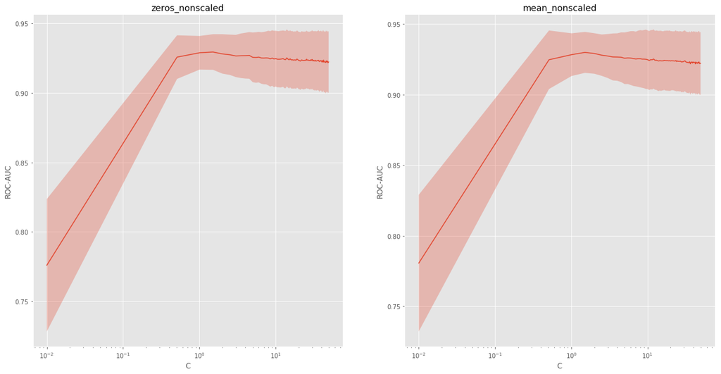

```python
plot_scores(opt1_z, opt1_m,["zeros_nonscaled","mean_nonscaled"])
```

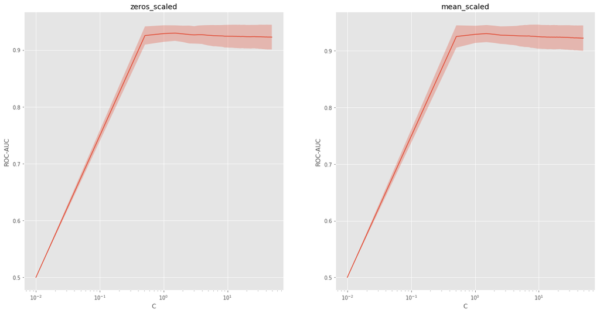

```python
plot_scores(opt1_zs, opt1_ms,["zeros_scaled","mean_scaled"])
```

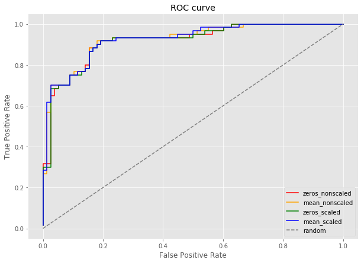

```python
fpr1, tpr1, _ = roc_curve(y_test, opt1_z.predict_proba(X_test_zeros)[:,1])
fpr2, tpr2, _ = roc_curve(y_test, opt1_m.predict_proba(X_test_mean)[:,1])
fpr3, tpr3, _ = roc_curve(y_test, opt1_zs.predict_proba(X_test_zeros_scaled)[:,1])
fpr4, tpr4, _ = roc_curve(y_test, opt1_ms.predict_proba(X_test_mean_scaled)[:,1])
plot_roc((fpr1,fpr2, fpr3,fpr4), (tpr1, tpr2,tpr3, tpr4),
("zeros_nonscaled","mean_nonscaled", "zeros_scaled","mean_scaled"), ("red","orange","green","blue"))
```

```python
print_results1()
```

```
Для zeros_nonscaled
Лучший ROC-AUC на обучении:  0.9295
Лучший ROC-AUC на отложенной выборке:  0.83141
С:  1.0


Для mean_nonscaled
Лучший ROC-AUC на обучении:  0.9299
Лучший ROC-AUC на отложенной выборке:  0.823077
С:  1.0


Для zeros_scaled
Лучший ROC-AUC на обучении:  0.9297
Лучший ROC-AUC на отложенной выборке:  0.839744
С:  1.0


Для mean_scaled
Лучший ROC-AUC на обучении:  0.9303
Лучший ROC-AUC на отложенной выборке:  0.83141
С:  1.0
```

Стандартизация повысила roc-auc на обоих выборках.

Столь малое влияние нормализации в обоих случаях проявляется потому, что элементов с большим отклоением в исходной выборке было мало

## Заключение:

### Материалы:

1) Видеолекции Школы анализа данных, https://yandexdataschool.ru/

2) http://scikit-learn.org/

# Спасибо за внимание!